# Leitura de Microdados IBGE

- São Arquivos com formato especial **largura fixa**
- A largura fixa é como se representa a divisão das variáveis em um registro

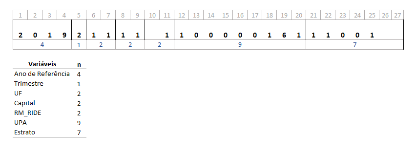

## Vantagens

- muito compacta - menor tamanho do arquivo para armazenamento
- rápido de acessar com um software adequado

## Desvantagem

- Necessita de um arquivo auxiliar (dicionário) com as *larguras* e identificação das variáveis
- É necessários construir o código descrevendo as posições

## Lendo arquivo Morador - POF

```r
MORADOR <-
  read.fwf("../pof/MORADOR.txt"
    , widths = c(2,4,1,9,2,1,2,2,1,2,2,4,3,1,1,14,14,10)
    , na.strings=c(" ")
    , col.names = c("UF"
               , "ESTRATO_POF", "TIPO_SITUACAO_REG"
               , "COD_UPA", "NUM_DOM", "NUM_UC"
               , "COD_INFORMANTE", "V0306", "V0401"
               , "V04021", "V04022", "V04023", "V0403"
               , "V0404", "V0405", "PESO", "PESO_FINAL"
               , "RENDA_TOTAL")
           , dec="."
           )
```

## read.fwf

- esta função faz o trabalho, mas tem baixa performance
- no arquivo Morador com 13.1MB (178431,18)
- no r: object.size(MORADOR) - ~14MB
- tempo de leitura: ~72s (com arquivo em HD)

## Opção mais eficiente read_fwf

- é uma função do package **readr**
- observe que o comando é diferente (usa "_" como separador)
- os parâmetros também são diferentes
- é 300 vezes mais rápido (na leitura do exemplo MORADOR)

## Lendo arquivo Morador - POF (read_fwf)

```r
w=c(2,4,1,9,2,1,2,2,1,2,2,4,3,1,1,14,14,10)
end1=cumsum(x)
start1=end1-(x-1)
vars = c("UF", "ESTRATO_POF", "TIPO_SITUACAO_REG"
              , "COD_UPA", "NUM_DOM", "NUM_UC"
              , "COD_INFORMANTE", "V0306", "V0401"
              , "V04021", "V04022", "V04023", "V0403"
              , "V0404", "V0405", "PESO", "PESO_FINAL"
              , "RENDA_TOTAL")

MORADOR = readr::read_fwf("../pof/MORADOR.txt"
          ,col_positions = readr::fwf_widths(w, vars) )
```

## Leitura PNAD-Contínua

- há um package que facilita a leitura: PNADcIBGE
- package feito pelo IBGE
- Está disponivel no site do R (CRAN)
- use: **install.packages(“PNADcIBGE”)**

## PNADcIBGE - get_pnadc

- get_pnadc: faz o download e leitura de um arquivo PNAD_c

```r
get_pnadc(year, quarter = NULL, interview = NULL,
  vars = NULL,  labels = T, design = T,
  savedir = tempdir())
```

## PNADcIBGE - read_pnadc

- read_pnadc: faz leitura de um arquivo PNAD_c

```r
read_pnadc(microdata, input_txt, vars = NULL)
```

- microdata - arquivo txt da PNADc
- input_txt - arquivo txt com o código de leitura SAS
- vars - variáveis desejadas

## Lendo dados PNADc - comandos

```r
input_path <- pnadc_example(path="input_example.txt")
data_path <- pnadc_example(path="exampledata.txt")
pnadc.df <- read_pnadc(microdata=data_path,
                input_txt=input_path, vars="VD4002")
```

## input_example.txt

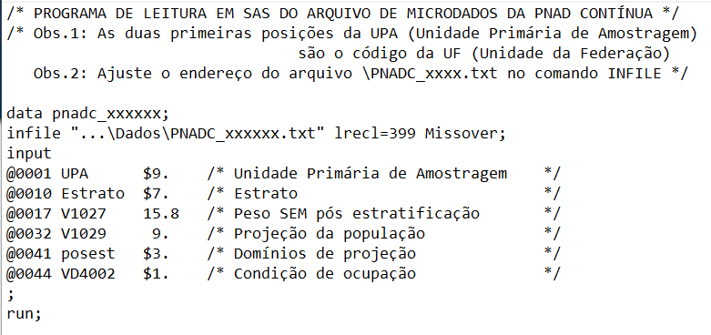

## exampledata.txt

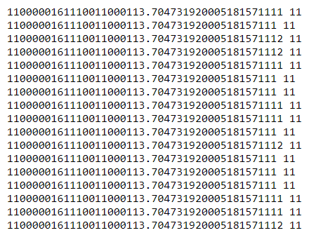

## Lendo dados PNADc - comandos

```r
library(PNADcIBGE)
input_path <- pnadc_example(path="input_example.txt")
data_path <- pnadc_example(path="exampledata.txt")
pnadc.df <- read_pnadc(microdata=data_path,
                  input_txt=input_path, vars="VD4002")

head(pnadc.df,3)
```

```
## # A tibble: 3 x 9
##   Ano   Trimestre UF    UPA       Estrato V1027   V1029 posest VD4002
##   <chr> <chr>     <chr> <chr>     <chr>   <dbl>   <dbl> <chr>  <chr>
## 1 2017  4         11    110000016 1110011  121.  512631 111    1
## 2 2017  4         11    110000016 1110011  121.  512631 111    <NA>
## 3 2017  4         11    110000052 1152012  201. 1222291 114    1
```